# Tipología y ciclo de Vida de los datos. PRA2

Analizamos ahora los extremos en el número de familiares

```r
unique(boxplot.stats(data.train$Parch)$out)
```

```
## [1] 1 2 5 3 4 6
```

Se registran como valores extremos todo lo que sea diferente a 0. Los pasajeros con 0 hermanos a bordo serán la norma, pero no parece descabellado que haya grupos de hermanos a bordo, por lo quedaremos directamente por buenos los valores diferentes a cero que no sean muy elevados. Como en el caso de los hermanos sólo inspeccionaremos los dos valores más extremos, en este caso 5 y 6.

```r
data.train[data.train$Parch==5,c(3,4,6,7,8,9)]
```

```
##            Pclass                                                      Name Age
## 14  Tercera clase                               Andersson, Mr. Anders Johan  39
## 26  Tercera clase Asplund, Mrs. Carl Oscar (Selma Augusta Emilia Johansson)  38
## 611 Tercera clase Andersson, Mrs. Anders Johan (Alfrida Konstantia Brogren)  39
## 639 Tercera clase                    Panula, Mrs. Juha (Maria Emilia Ojala)  41
## 886 Tercera clase                      Rice, Mrs. William (Margaret Norton)  39
##     SibSp Parch  Ticket
## 14      1     5  347082
## 26      1     5  347077
## 611     1     5  347082
## 639     0     5 3101295
## 886     0     5  382652
```

Si miramos los datos de los tickets de las personas que tienen 5 familiares a bordo podemos detectar si hay alguna anomalía

```r
data.train[data.train$Ticket=="347082",c(3,4,6,7,8,9)]
```

```
##            Pclass                                                      Name Age
## 14  Tercera clase                               Andersson, Mr. Anders Johan  39
## 120 Tercera clase                         Andersson, Miss. Ellis Anna Maria   2
## 542 Tercera clase                      Andersson, Miss. Ingeborg Constanzia   9
## 543 Tercera clase                         Andersson, Miss. Sigrid Elisabeth  11
## 611 Tercera clase Andersson, Mrs. Anders Johan (Alfrida Konstantia Brogren)  39
## 814 Tercera clase                        Andersson, Miss. Ebba Iris Alfrida   6
## 851 Tercera clase                   Andersson, Master. Sigvard Harald Elias   4
##     SibSp Parch Ticket
## 14      1     5 347082
## 120     4     2 347082
## 542     4     2 347082
## 543     4     2 347082
## 611     1     5 347082
## 814     4     2 347082
## 851     4     2 347082
```

```r
data.train[data.train$Ticket=="347077",c(3,4,6,7,8,9)]
```

```
##            Pclass                                                      Name Age
## 26  Tercera clase Asplund, Mrs. Carl Oscar (Selma Augusta Emilia Johansson)  38
## 183 Tercera clase                     Asplund, Master. Clarence Gustaf Hugo   9
## 234 Tercera clase                            Asplund, Miss. Lillian Gertrud   5
## 262 Tercera clase                         Asplund, Master. Edvin Rojj Felix   3
##     SibSp Parch Ticket
## 26      1     5 347077
## 183     4     2 347077
## 234     4     2 347077
## 262     4     2 347077
```

```r
data.train[data.train$Ticket=="382652",c(3,4,6,7,8,9)]
```

```
##            Pclass                                 Name Age SibSp Parch Ticket
## 17  Tercera clase                 Rice, Master. Eugene   2     4     1 382652
## 172 Tercera clase                 Rice, Master. Arthur   4     4     1 382652
## 279 Tercera clase                   Rice, Master. Eric   7     4     1 382652
## 788 Tercera clase            Rice, Master. George Hugh   8     4     1 382652
## 886 Tercera clase Rice, Mrs. William (Margaret Norton)  39     0     5 382652
```

```r
data.train[data.train$Ticket=="3101295",c(3,4,6,7,8,9)]
```

```
##            Pclass                                   Name Age SibSp Parch
## 51  Tercera clase             Panula, Master. Juha Niilo   7     4     1
## 165 Tercera clase           Panula, Master. Eino Viljami   1     4     1
## 267 Tercera clase              Panula, Mr. Ernesti Arvid  16     4     1
## 639 Tercera clase Panula, Mrs. Juha (Maria Emilia Ojala)  41     0     5
## 687 Tercera clase               Panula, Mr. Jaako Arnold  14     4     1
## 825 Tercera clase           Panula, Master. Urho Abraham   2     4     1
##      Ticket
## 51  3101295
## 165 3101295
## 267 3101295
## 639 3101295
## 687 3101295
## 825 3101295
```

Parece todo correcto

Miramos el caso de 6 familiares

```r
data.train[data.train$Parch==6,c(3,4,6,7,8,9)]
```

```
##            Pclass                                    Name Age SibSp Parch
## 679 Tercera clase Goodwin, Mrs. Frederick (Augusta Tyler)  43     1     6
##      Ticket
## 679 CA 2144
```

```r
data.train[data.train$Ticket=="CA 2144",c(3,4,6,7,8,9)]
```

```
##            Pclass                                    Name Age SibSp Parch
## 60  Tercera clase      Goodwin, Master. William Frederick  11     5     2
## 72  Tercera clase              Goodwin, Miss. Lillian Amy  16     5     2
## 387 Tercera clase         Goodwin, Master. Sidney Leonard   1     5     2
## 481 Tercera clase          Goodwin, Master. Harold Victor   9     5     2
## 679 Tercera clase Goodwin, Mrs. Frederick (Augusta Tyler)  43     1     6
## 684 Tercera clase             Goodwin, Mr. Charles Edward  14     5     2
##      Ticket
## 60  CA 2144
## 72  CA 2144
## 387 CA 2144
## 481 CA 2144
## 679 CA 2144
## 684 CA 2144
```

En este caso parece todo correcto, pues faltarían un marido y un hijo que estarán en el data.test.

Para analizar los precios de los tickets lo haremos por clases en lugar de con toda la muestra, pues nos ayudará a identificar mejor las anomalías en esta variable

```r
data.train.firstclass<-data.train[data.train$Pclass=="Primera clase",]
unique(boxplot.stats(data.train.firstclass$Fare)$out)
```

```
## [1] 263.0000 247.5208 512.3292 262.3750 211.5000 227.5250 221.7792 211.3375
```

Todos los valores detectados están en órdenes de magnitud parecidos, excepto el que supera 500. Miramos este caso, pues los demás son totalmente aceptables

```r
data.train[data.train$Fare>500,c(3,4,6,7,8,9,10)]
```

```
##            Pclass                               Name Age SibSp Parch   Ticket
## 259 Primera clase                   Ward, Miss. Anna  35     0     0 PC 17755
## 680 Primera clase Cardeza, Mr. Thomas Drake Martinez  36     0     1 PC 17755
## 738 Primera clase             Lesurer, Mr. Gustave J  35     0     0 PC 17755
##         Fare
## 259 512.3292
## 680 512.3292
## 738 512.3292
```

```r
data.train.secondclass<-data.train[data.train$Pclass=="Segunda clase",]
unique(boxplot.stats(data.train.secondclass$Fare)$out)
```

```
## [1] 73.5 65.0
```

Para la segunda clase parecen del todo razonables los valores detectados como extremos

Analizamos ahora la tercera clase

```r
data.train.thirdclass<-data.train[data.train$Pclass=="Tercera clase",]
unique(boxplot.stats(data.train.thirdclass$Fare)$out)
```

```
## [1] 31.2750 29.1250 31.3875 39.6875 46.9000 27.9000 56.4958 34.3750 69.5500
```

Aquí llama la atención los valores que superan los 50 dólares, pues serían muy altos incluso para la segunda clase. Miramos si hay muchas personas en el ticket y si no fuera así, deberíamos aplicar alguna corrección o marcarlos como “sospechosos”

```r
data.train.thirdclass[data.train.thirdclass$Fare>50,c(3,4,6,7,8,9,10)]
```

```
##            Pclass                              Name Age SibSp Parch   Ticket
## 75  Tercera clase                     Bing, Mr. Lee  32     0     0     1601
## 160 Tercera clase        Sage, Master. Thomas Henry   9     8     2 CA. 2343
## 170 Tercera clase                     Ling, Mr. Lee  28     0     0     1601
## 181 Tercera clase      Sage, Miss. Constance Gladys   9     8     2 CA. 2343
## 202 Tercera clase               Sage, Mr. Frederick   9     8     2 CA. 2343
## 325 Tercera clase          Sage, Mr. George John Jr   9     8     2 CA. 2343
## 510 Tercera clase                    Lang, Mr. Fang  26     0     0     1601
## 644 Tercera clase                   Foo, Mr. Choong  29     0     0     1601
## 693 Tercera clase                      Lam, Mr. Ali  29     0     0     1601
## 793 Tercera clase           Sage, Miss. Stella Anna   9     8     2 CA. 2343
## 827 Tercera clase                      Lam, Mr. Len  32     0     0     1601
## 839 Tercera clase                   Chip, Mr. Chang  32     0     0     1601
## 847 Tercera clase          Sage, Mr. Douglas Bullen  11     8     2 CA. 2343
## 864 Tercera clase Sage, Miss. Dorothy Edith "Dolly"   9     8     2 CA. 2343
##        Fare
## 75  56.4958
## 160 69.5500
## 170 56.4958
## 181 69.5500
## 202 69.5500
## 325 69.5500
## 510 56.4958
## 644 56.4958
## 693 56.4958
## 793 69.5500
## 827 56.4958
## 839 56.4958
## 847 69.5500
## 864 69.5500
```

Observamos que estos precios corresponden con dos tickets de 7 personas cada una, por lo que consideramos que los valores son razonables.

# 4. Análisis de los datos

Añadimos dos nuevas variables para facilitar el análisis de la supervivencia, que es la variable en la que centraremos nuestro análisis

```r
# Añadimos variable FamilyMembers
data.train$FamilyMembers <- as.integer(data.train$SibSp + data.train$Parch + 1)
# Añadimos variable FarePerPassenger
data.train$FarePerPassenger <- data.train$Fare / data.train$FamilyMembers
# Discretizamos FarePerPassenger
data.train$FarePerPassengerSegments <- discretize(data.train$FarePerPassenger, method = "interval", breaks = 8)
```

Exportación de los datos preprocesados

```r
write.csv(data.train, file="./titanic/train_clean.csv", row.names= FALSE)
```

Analizamos la supervivencia según las otras variables como exploración previa de los datos para seleccionar los grupos a analizar

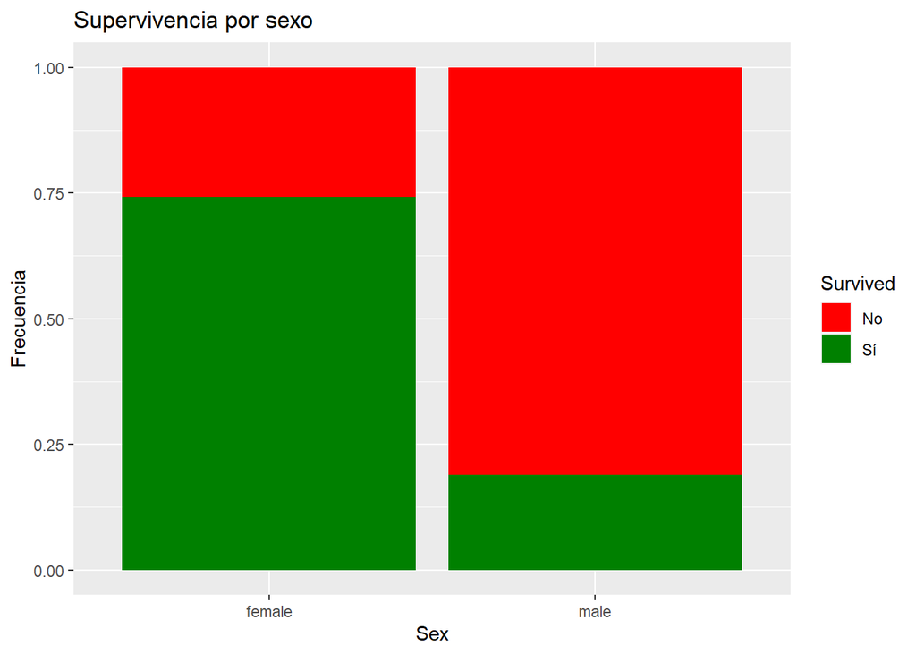

```r
# Survived como función de Sex
ggplot(data = data.train[1:dim(data.train)[1],],aes(x=Sex,fill=Survived))+geom_bar(position="fill")+scale_fill_manual(values=c("#FF0000","#008000"))+ylab("Frecuencia")+labs(title="Supervivencia por sexo")
```

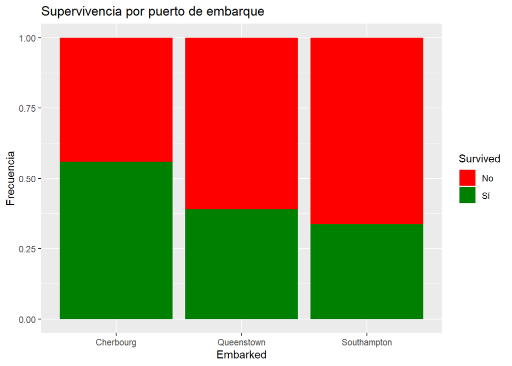

```r
#Survived como función de Embarked:
ggplot(data = data.train[1:dim(data.train)[1],],aes(x=Embarked,fill=Survived))+geom_bar(position="fill")+scale_fill_manual(values=c("#FF0000","#008000"))+ylab("Frecuencia")+labs(title="Supervivencia por puerto de embarque")
```

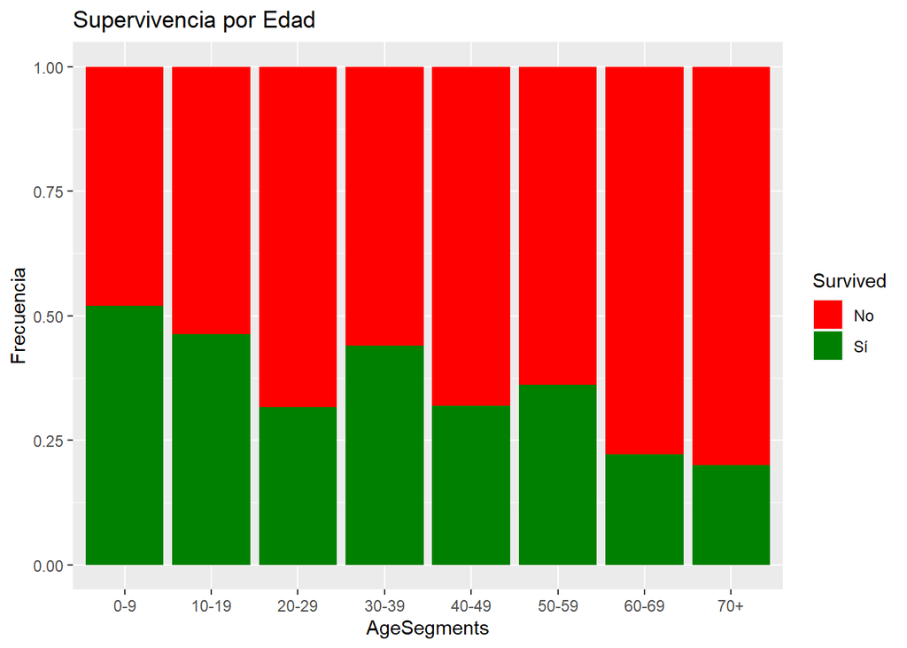

```r
#Survived como función de AgeSegments:
ggplot(data = data.train[1:dim(data.train)[1],],aes(x=AgeSegments,fill=Survived))+geom_bar(position="fill")+scale_fill_manual(values=c("#FF0000","#008000"))+ylab("Frecuencia")+labs(title="Supervivencia por Edad")
```

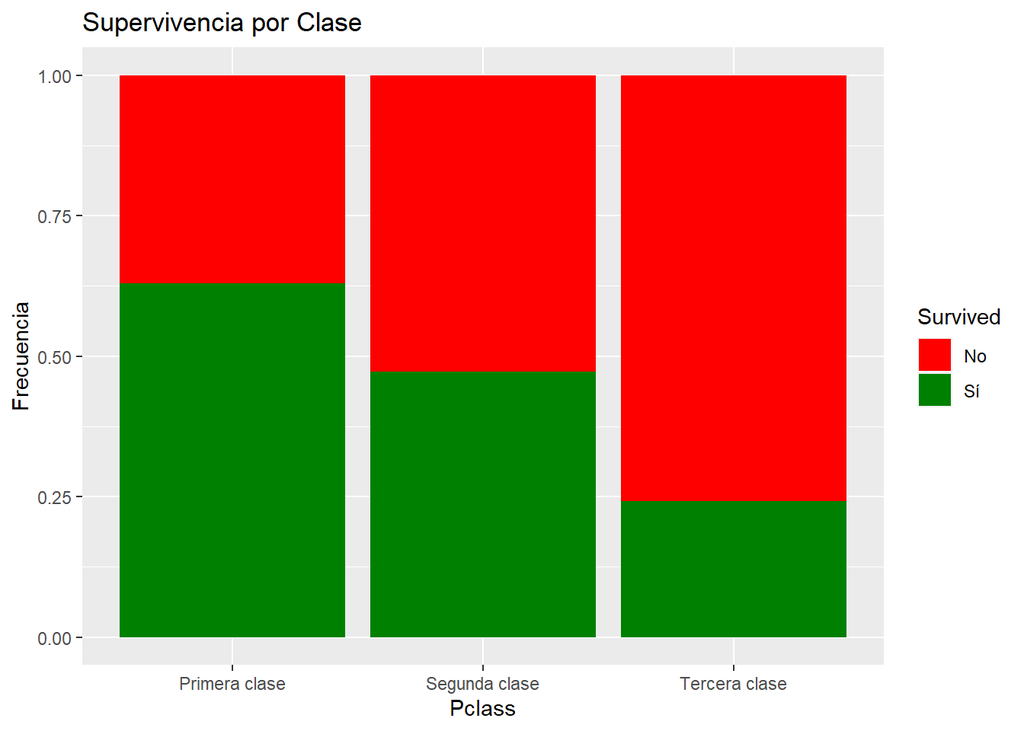

```r
#Survived como función de Pclass:
ggplot(data = data.train[1:dim(data.train)[1],],aes(x=Pclass,fill=Survived))+geom_bar(position="fill")+scale_fill_manual(values=c("#FF0000","#008000"))+ylab("Frecuencia")+labs(title="Supervivencia por Clase")
```

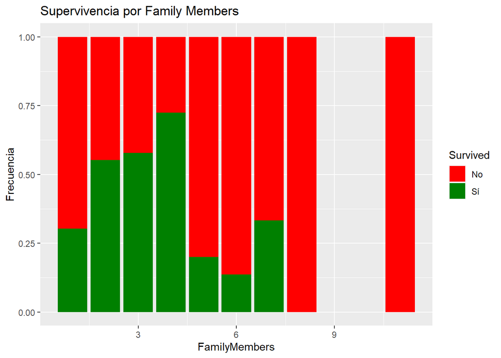

```r
#Survived como función de FamilyMembers:
ggplot(data = data.train[1:dim(data.train)[1],],aes(x=FamilyMembers,fill=Survived))+geom_bar(position="fill")+scale_fill_manual(values=c("#FF0000","#008000"))+ylab("Frecuencia")+labs(title="Supervivencia por Family Members")
```

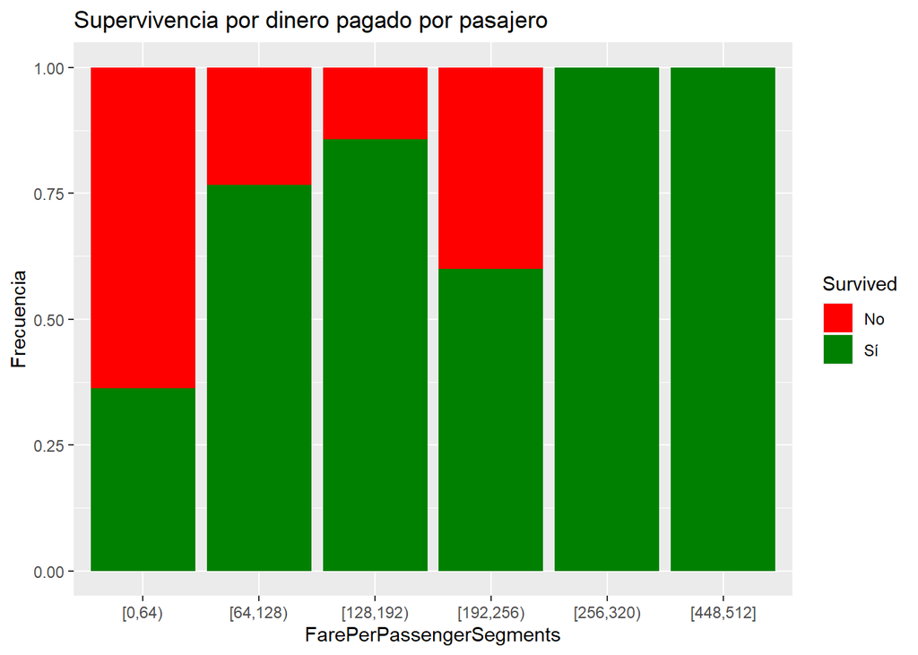

```r
#Survived como función de FarePerPassengerSegments:
ggplot(data = data.train[1:dim(data.train)[1],],aes(x=FarePerPassengerSegments,fill=Survived))+geom_bar(position="fill")+scale_fill_manual(values=c("#FF0000","#008000"))+ylab("Frecuencia")+labs(title="Supervivencia por dinero pagado por pasajero")
```

## 4.1. Selección de los grupos de datos que se quieren analizar/comparar (planificación de los análisis a aplicar)

Tras mirar las distribuciones previas nos puede interesar comparar entre clases, entres sexos y entre puertos de embarque, por lo que creamos los distintos grupos que podemos utilizar

```r
# División en clases
primera_clase <- data.train[data.train$Pclass=="Primera clase",]
segunda_clase <- data.train[data.train$Pclass=="Segunda clase",]
tercera_clase <- data.train[data.train$Pclass=="Tercera clase",]
# División por supervivencia
sobrevive <- data.train[data.train$Survived=="Sí",]
no_sobrevive <- data.train[data.train$Survived=="No",]
# División por sexos
hombre <- data.train[data.train$Sex=="male",]
mujer <- data.train[data.train$Sex=="female",]
# División por puerto de embarque
southampton <- data.train[data.train$Embarked=="Southampton",]
cherbourg <- data.train[data.train$Embarked=="Cherbourg",]
queenstown <- data.train[data.train$Embarked=="Queenstown",]
```

## 4.2. Comprobación de la normalidad y homogeneidad de la varianza.

El siguiente paso será comprobar que nuestras variables cuantitativas tienen una distribución normal y que sus varianzas son homogéneas. Todas nuestras variables excepto Fare y Age son etiquetas descriptivas, por lo que sólo deberemos hacer los tests de normalidad homocedasticidad a estas dos.

Por el teorema del límite central podríamos asumir normalidad en todos los casos, pues siempre tenemos un número de muestras mayor que 30, pero vamos a asegurarnos. Aplcamis primero el test de Shapiro a ambas variables para comprobar si podemos rechazar la hipótesis nula de que la distribución no es normal con un intervalo de confianza del 95 %

```r
shapiro.test(data.train$Age)
```

```
##
##  Shapiro-Wilk normality test
##
## data:  data.train$Age
## W = 0.9824, p-value = 7.011e-09
```

```r
shapiro.test(data.train$Fare)
```

```
##
##  Shapiro-Wilk normality test
##
## data:  data.train$Fare
## W = 0.52189, p-value < 2.2e-16
```

```r
leveneTest(data.train$Age~data.train$Pclass)
```

```
## Levene's Test for Homogeneity of Variance (center = median)
##        Df F value    Pr(>F)
## group   2  7.2916 0.0007228 ***
##       888
## ---
## Signif. codes:  0 '***' 0.001 '**' 0.01 '*' 0.05 '.' 0.1 ' ' 1
```

```r
leveneTest(data.train$Age~data.train$Sex)
```

```
## Levene's Test for Homogeneity of Variance (center = median)
##        Df F value Pr(>F)
## group   1  0.7836 0.3763
##       889
```

```r
leveneTest(data.train$Age~data.train$Embarked)
```

```
## Levene's Test for Homogeneity of Variance (center = median)
##        Df F value Pr(>F)
## group   2  0.3627 0.6959
##       888
```

```r
leveneTest(data.train$Age~data.train$Survived)
```

```
## Levene's Test for Homogeneity of Variance (center = median)
##        Df F value Pr(>F)
## group   1   2.608 0.1067
##       889
```

Observamos que la edad presenta varianzas distintas según la clase (el p-valor es menor que 0.05 y rechazamos la hipótesis nula). En el caso del sexo, puerto de embarque y supervivencia tendríamos varianzas de edad muy similares para los distintos grupos de cada variable.

```r
leveneTest(data.train$Fare~data.train$Pclass)
```

```
## Levene's Test for Homogeneity of Variance (center = median)
##        Df F value    Pr(>F)
## group   2  118.57 < 2.2e-16 ***
##       888
## ---
## Signif. codes:  0 '***' 0.001 '**' 0.01 '*' 0.05 '.' 0.1 ' ' 1
```

```r
leveneTest(data.train$Fare~data.train$Sex)
```

```
## Levene's Test for Homogeneity of Variance (center = median)
##        Df F value    Pr(>F)
## group   1  19.188 1.326e-05 ***
##       889
## ---
## Signif. codes:  0 '***' 0.001 '**' 0.01 '*' 0.05 '.' 0.1 ' ' 1
```

```r
leveneTest(data.train$Fare~data.train$Embarked)
```

```
## Levene's Test for Homogeneity of Variance (center = median)
##        Df F value    Pr(>F)
## group   2  33.539 9.082e-15 ***
##       888
## ---
## Signif. codes:  0 '***' 0.001 '**' 0.01 '*' 0.05 '.' 0.1 ' ' 1
```

```r
leveneTest(data.train$Fare~data.train$Survived)
```

```
## Levene's Test for Homogeneity of Variance (center = median)
##        Df F value    Pr(>F)
## group   1    45.1 3.337e-11 ***
##       889
## ---
## Signif. codes:  0 '***' 0.001 '**' 0.01 '*' 0.05 '.' 0.1 ' ' 1
```

## 4.3. Aplicación de pruebas estadísticas para comparar los grupos de datos.

En función de los datos y el objetivo del estudio, aplicar pruebas de contraste de hipótesis, correlaciones, regresiones, etc. Aplicar al menos tres métodos de análisis diferentes.

Vamos a hacer un test de hipotésis sobre la proporción de supervivientes dependiendo de la clase en la que viajaba el pasajero.

Hacemos un test sobre la proporción de supervivientes con 3 muestras, una para cada clase.

```r
p_sob_primera <- nrow(primera_clase[primera_clase$Survived=="Sí",])/nrow(primera_clase)
p_sob_segunda <- nrow(segunda_clase[segunda_clase$Survived=="Sí",])/nrow(segunda_clase)
p_sob_tercera <- nrow(tercera_clase[tercera_clase$Survived=="Sí",])/nrow(tercera_clase)
sob <-  c(p_sob_primera*nrow(primera_clase),p_sob_segunda*nrow(segunda_clase),p_sob_tercera*nrow(tercera_clase))
nn <- c(nrow(primera_clase),nrow(segunda_clase),nrow(tercera_clase))
prop.test(sob,nn,alternative="two.sided",correct=FALSE)
```

```
##
##  3-sample test for equality of proportions without continuity
##  correction
##
## data:  sob out of nn
## X-squared = 102.89, df = 2, p-value < 2.2e-16
## alternative hypothesis: two.sided
## sample estimates:
##    prop 1    prop 2    prop 3
## 0.6296296 0.4728261 0.2423625
```

El p-valor de 2.2e-16, mucho menor a 0.05, nos hace rechazar la hipótesis nula, por lo que podemos concluir que cada grupo tiene una proporción de supervivientes bastante diferenciada, centrada en los siguientes valores:

Primera clase: 62.96 % de supervivientes

Segunda clase: 47.28 % de supervivientes

Tercera clase: 24.23 % de supervivientes

Vamos a hacer un test de hipotésis sobre la proporción de supervivientes dependiendo del sexo del pasajero.

Hacemos un test sobre la proporción de supervivientes con 2 muestras, una para cada sexo.

```r
p_sob_mujeres <- nrow(mujer[mujer$Survived=="Sí",])/nrow(mujer)
p_sob_hombres <- nrow(hombre[hombre$Survived=="Sí",])/nrow(hombre)
sob <-  c(p_sob_mujeres*nrow(mujer),p_sob_hombres*nrow(hombre))
nn <- c(nrow(mujer),nrow(hombre))
prop.test(sob,nn,alternative="two.sided",correct=FALSE)
```

```
##
##  2-sample test for equality of proportions without continuity
##  correction
##
## data:  sob out of nn
## X-squared = 263.05, df = 1, p-value < 2.2e-16
## alternative hypothesis: two.sided
## 95 percent confidence interval:
##  0.4951483 0.6111119
## sample estimates:
##    prop 1    prop 2
## 0.7420382 0.1889081
```

El p-valor de 2.2e-16, mucho menor a 0.05, nos hace rechazar la hipótesis nula, por lo que podemos concluir que cada grupo tiene una proporción de supervivientes bastante diferenciada, centrada en los siguientes valores:

Mujeres: 74.20 % de supervivientes

Hombres: 18.89 % de supervivientes

Vamos a hacer un test de hipotésis sobre la proporción de supervivientes dependiendo del puerto de embarque del pasajero.

Hacemos un test sobre la proporción de supervivientes con 3 muestras, una para cada puerto de embarque.

```r
p_sob_southampton <- nrow(southampton[southampton$Survived=="Sí",])/nrow(southampton)
p_sob_cherbourg <- nrow(cherbourg[cherbourg$Survived=="Sí",])/nrow(cherbourg)
p_sob_queenstown <- nrow(queenstown[queenstown$Survived=="Sí",])/nrow(queenstown)
sob <-  c(p_sob_southampton*nrow(southampton),p_sob_cherbourg*nrow(cherbourg),p_sob_tercera*nrow(queenstown))
nn <- c(nrow(southampton),nrow(cherbourg),nrow(queenstown))
prop.test(sob,nn,alternative="two.sided",correct=FALSE)
```

```
##
##  3-sample test for equality of proportions without continuity
##  correction
##
## data:  sob out of nn
## X-squared = 34.354, df = 2, p-value = 3.469e-08
## alternative hypothesis: two.sided
## sample estimates:
##    prop 1    prop 2    prop 3
## 0.3369565 0.5588235 0.2423625
```

southampton: 33.69 % de supervivientes

cherbourg: 55.88 % de supervivientes

En el test de correlación vamos a mirar primero las correlaciones entre sobrevivir y alguna variables numéricas

```r
data.train$SurvivedInt <- as.integer(ifelse(data.train$Survived=="Sí",1,0))
cor_FarePerPassenger <- cor.test(data.train$FarePerPassenger,data.train$SurvivedInt)
cor_FarePerPassenger
```

```
##
##  Pearson's product-moment correlation
##
## data:  data.train$FarePerPassenger and data.train$SurvivedInt
## t = 6.7757, df = 889, p-value = 2.251e-11
## alternative hypothesis: true correlation is not equal to 0
## 95 percent confidence interval:
##  0.1582253 0.2831562
## sample estimates:
##       cor
## 0.2215999
```

```r
cor_Age <- cor.test(data.train$Age,data.train$SurvivedInt)
cor_Age
```

```
##
##  Pearson's product-moment correlation
##
## data:  data.train$Age and data.train$SurvivedInt
## t = -2.9522, df = 889, p-value = 0.003238
## alternative hypothesis: true correlation is not equal to 0
## 95 percent confidence interval:
##  -0.16315413 -0.03306915
## sample estimates:
##         cor
## -0.09853255
```

```r
cor_SibSp <- cor.test(data.train$SibSp,data.train$SurvivedInt)
cor_SibSp
```

```
##
##  Pearson's product-moment correlation
##
## data:  data.train$SibSp and data.train$SurvivedInt
## t = -1.0538, df = 889, p-value = 0.2922
## alternative hypothesis: true correlation is not equal to 0
## 95 percent confidence interval:
##  -0.10076614  0.03042549
## sample estimates:
##        cor
## -0.0353225
```

No obstante, para la dependencia de la supervivencia con el precio del billete por pasajero sí que hay un p-valor muy pequeño que permite rechazar la hipótesis nula y la correlación es de 0.22. Esta correlación no es excesivamente grande, pero teniendo en cuenta que sobrevivir es una variable binaria que da 0 o 1, una correlación de 0.22 será muy a tener en cuenta.

Para finalizar vamos a usar una regresión logística para predecir la probabilidad de supervivencia en función de las variables que hemos encontrado que puedan tener algún efecto en la misma. Nos decantamos por usar el sexo, el puerto de embarque, la clase y el precio.

```r
glm_sobrevivir <- glm(formula =Survived~Sex+Embarked+Pclass+FarePerPassenger, family=binomial(link=logit),data=data.train)
summary(glm_sobrevivir)
```

```
##
## Call:
## glm(formula = Survived ~ Sex + Embarked + Pclass + FarePerPassenger,
##     family = binomial(link = logit), data = data.train)
##
## Deviance Residuals:
##     Min       1Q   Median       3Q      Max
## -2.2914  -0.7140  -0.4181   0.6707   2.2394
##
## Coefficients:
##                      Estimate Std. Error z value Pr(>|z|)
## (Intercept)          2.442059   0.322893   7.563 3.94e-14 ***
## Sexmale             -2.604784   0.185739 -14.024  < 2e-16 ***
## EmbarkedQueenstown  -0.113224   0.363962  -0.311   0.7557
## EmbarkedSouthampton -0.557462   0.231102  -2.412   0.0159 *
## PclassSegunda clase -0.556207   0.273310  -2.035   0.0418 *
## PclassTercera clase -1.702389   0.257509  -6.611 3.82e-11 ***
## FarePerPassenger     0.003764   0.003503   1.075   0.2826
## ---
## Signif. codes:  0 '***' 0.001 '**' 0.01 '*' 0.05 '.' 0.1 ' ' 1
##
## (Dispersion parameter for binomial family taken to be 1)
##
##     Null deviance: 1186.66  on 890  degrees of freedom
## Residual deviance:  817.44  on 884  degrees of freedom
## AIC: 831.44
##
## Number of Fisher Scoring iterations: 5
```

Concluimos de este modelo que las variables que más influyen en la no supervivencia son ser hombre y ser de tercera clase, pues tenemos unos p-valores muy pequeños para ambas variables en el modelo.

Creado el modelo miramos la tabla de confusión de las predicciones hechas con el mismo y lo comparamos con las personas que han sobrevivido

```r
library(caret)
library(e1071)
predicted_data <- predict(glm_sobrevivir, data.train)
predicted_survival <- as.factor(ifelse(predicted_data>0.5,"Sí","No"))
cm <- confusionMatrix(predicted_survival,data.train$Survived)
cm$table
```

```
##           Reference
## Prediction  No  Sí
##         No 522 140
##         Sí  27 202
```

# 5. Representación de los resultados a partir de tablas y gráficas.

Podemos comprobar gráficamente la conclusión que estrajimos, las variables que más influyen en la no supervivencia son ser hombre y viajar en tercera clase

Grafico: proporción de supervivientes por clase

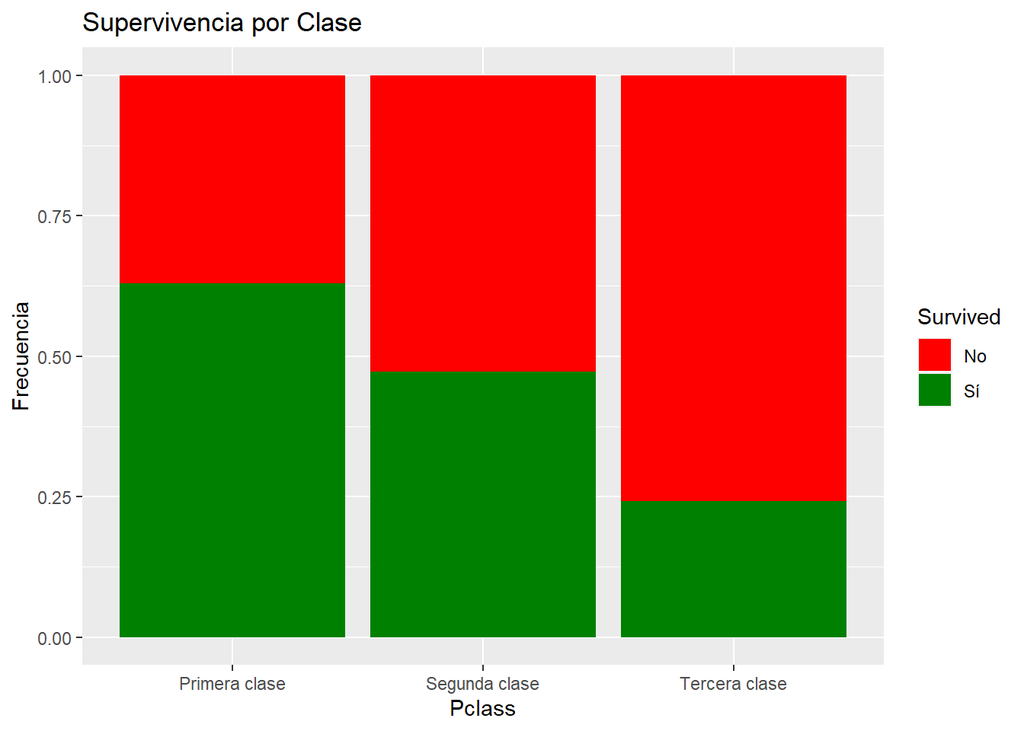

```r
#Survived como función de Pclass:
ggplot(data = data.train,aes(x=Pclass,fill=Survived))+geom_bar(position="fill")+scale_fill_manual(values=c("#FF0000","#008000"))+ylab("Frecuencia")+labs(title="Supervivencia por Clase")
```

Primera clase: 62.96 % de supervivientes

Segunda clase: 47.28 % de supervivientes

Tercera clase: 24.23 % de supervivientes

Tabla de contingencia: supervivientes por clase

```r
SurvivedClass <- table(data.train$Pclass,data.train$Survived)
SurvivedClass
```

```
##
##                  No  Sí
##   Primera clase  80 136
##   Segunda clase  97  87
##   Tercera clase 372 119
```

```r
prop.table(SurvivedClass, margin = 1)
```

```
##
##                        No        Sí
##   Primera clase 0.3703704 0.6296296
##   Segunda clase 0.5271739 0.4728261
##   Tercera clase 0.7576375 0.2423625
```

Grafico: proporción de supervivientes por sexo

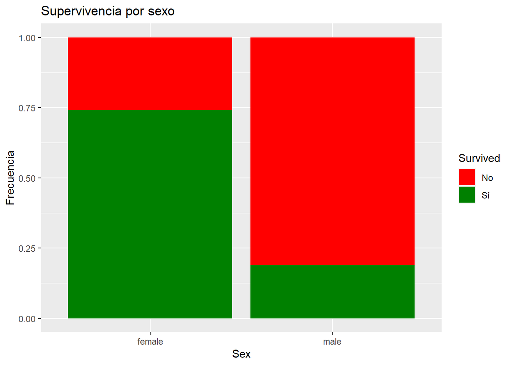

```r
# Survived como función de Sex
ggplot(data = data.train[1:dim(data.train)[1],],aes(x=Sex,fill=Survived))+geom_bar(position="fill")+scale_fill_manual(values=c("#FF0000","#008000"))+ylab("Frecuencia")+labs(title="Supervivencia por sexo")
```

Mujeres: 74.20 % de supervivientes

Hombres: 18.89 % de supervivientes

Tabla de contingencia: supervivientes por sexo

```r
SurvivedSex <- table(data.train$Sex, data.train$Survived)
SurvivedSex
```

```
##
##           No  Sí
##   female  81 233
##   male   468 109
```

```r
prop.table(SurvivedSex, margin = 1)
```

```
##
##                 No        Sí
##   female 0.2579618 0.7420382
##   male   0.8110919 0.1889081
```

Grafico: proporción de supervivientes por puerto de embarque

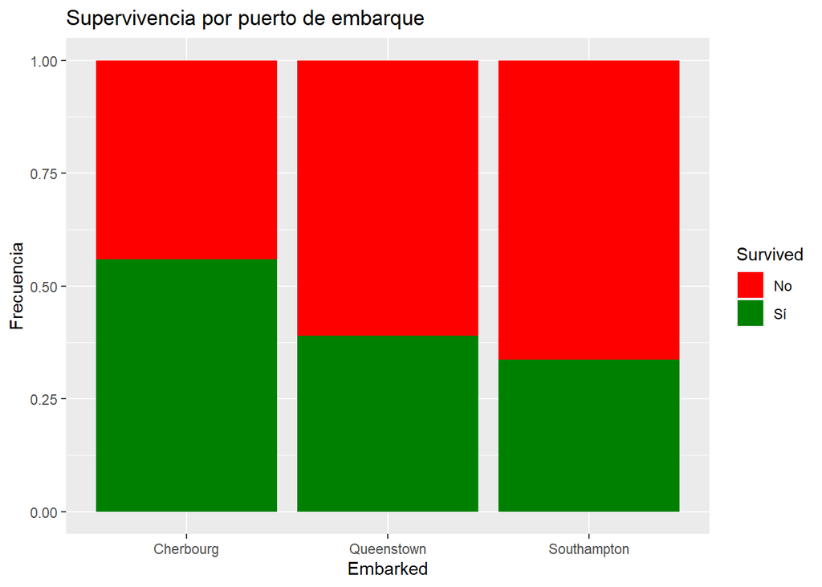

```r
#Survived como función de Embarked:
ggplot(data = data.train,aes(x=Embarked,fill=Survived))+geom_bar(position="fill")+scale_fill_manual(values=c("#FF0000","#008000"))+ylab("Frecuencia")+labs(title="Supervivencia por puerto de embarque")
```

Cherbourg: 55.88 % de supervivientes

Queenstown: 38.96 % de supervivientes

Southampton: 33.69 % de supervivientes

Tabla de contingencia: supervivientes por puerto de embarque

```r
SurvivedClass <- table(data.train$Embarked,data.train$Survived)
SurvivedClass
```

```
##
##                No  Sí
##   Cherbourg    75  95
##   Queenstown   47  30
##   Southampton 427 217
```

```r
prop.table(SurvivedClass, margin = 1)
```

```
##
##                      No        Sí
##   Cherbourg   0.4411765 0.5588235
##   Queenstown  0.6103896 0.3896104
##   Southampton 0.6630435 0.3369565
```

Correlaciones entre sobrevivir y FarePerPassenger, Age y SibSp

```r
# Tabla con las correlaciones  entre sobrevivir y FarePerPassenger, Age y SibSp
tabla.correlaciones <- matrix(c(cor_FarePerPassenger$estimate,cor_Age$estimate,cor_SibSp$estimate),ncol = 3, byrow = TRUE)
colnames(tabla.correlaciones) <- c("Correlación FarePerPassenger", "Correlación Age", "Correlación SibSp")
tabla.correlaciones
```

```
##      Correlación FarePerPassenger Correlación Age Correlación SibSp
## [1,]                    0.2215999     -0.09853255        -0.0353225
```

Regresión logística

Representación de la curva ROC

```r
library(pROC)
r=roc(data.train$Survived,predicted_data , data=data.train)
```

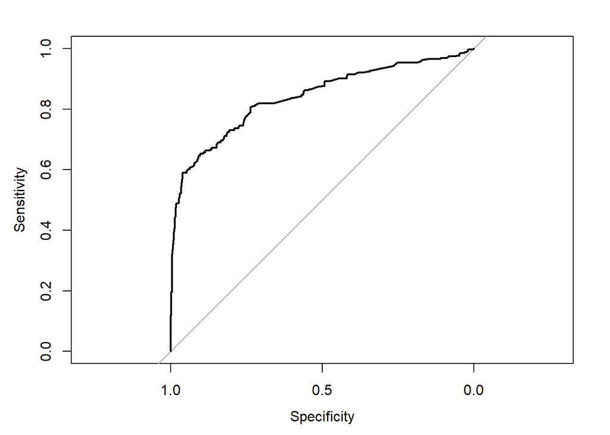

```r
plot(r)
```

```r
auc(r)
```

```
## Area under the curve: 0.8399
```

# 6. Resolución del problema. Conclusiones.

#### Para la resolución realizamos las siguientes acciones y extrajimos las correspondientes conclusiones

#### Realizamos un test sobre la proporción de supervivientes con 3 muestras, una para cada clase, y concluimos que cada grupo tiene una proporción de supervivientes bastante diferenciada, centrada en los siguientes valores:

Primera clase: 62.96 % de supervivientes

Segunda clase: 47.28 % de supervivientes

Tercera clase: 24.23 % de supervivientes

#### Realizamos un test sobre la proporción de supervivientes con 2 muestras, una para cada sexo, y concluimos que cada grupo tiene una proporción de supervivientes bastante diferenciada, centrada en los siguientes valores:

Mujeres: 74.20 % de supervivientes

Hombres: 18.89 % de supervivientes

#### Realizamos un test sobre la proporción de supervivientes con 3 muestras, una para cada puerto de embarque, y concluimos que cada grupo tiene una proporción de supervivientes bastante diferenciada, centrada en los siguientes valores:

Cherbourg: 55.88 % de supervivientes

Southampton: 33.69 % de supervivientes

#### Realizamos test de correlación entre sobrevivir y las variables numéricas FarePerPassenger, Age y SibSp, y concluímos que:

La correlación entre la edad, el número de hermanos o cónyugues y la supervivencia es prácticamente inexistente.

La correlación del precio del billete por pasajero y la supervivencia no es excesivamente grande, pero teniendo en cuenta que sobrevivir es una variable binaria que da 0 o 1, una correlación de 0.22 será muy a tener en cuenta

# Tabla de contribuciones

| Contribuciones | Firma |
| --- | --- |
| Investigación previa | EJAO, SFB |
| Redacción de las respuestas | EJAO, SFB |
| Desarrollo código | EJAO, SFB |